# Introduction to Bulk RNAseq data analysis

Obtaining RNA-seq reads from public repositories

## Introduction

Analysing an RNAseq experiment begins with sequencing reads. This tutorial explains how to begin by downloading the raw data files from the [NCBI Sequence Read Archive](https://trace.ncbi.nlm.nih.gov/Traces/sra/) public repository.

## The Dataset

The data for this course comes from a Frontiers in Microbiology paper, [Transcriptomic Profiling of Mouse Brain During Acute and Chronic Infections by Toxoplasma gondii Oocysts*](https://www.frontiersin.org/articles/10.3389/fmicb.2020.570903/full) (Hu et al. 2020). The raw data (sequence reads) can be downloaded from SRA under under the bio-project number PRJNA483261.

## Downloading raw data from SRA

Raw reads from sequencing experiments tend to be distributed through the Sequence Read Archive [SRA](https://trace.ncbi.nlm.nih.gov/Traces/sra/)). SRA provide command line tools for downloading and processing the archive files as the [SRA toolkit](https://trace.ncbi.nlm.nih.gov/Traces/sra/sra.cgi?view=software).

Alternatively the (*SRAdb*)[http://bioconductor.org/packages/release/bioc/html/SRAdb.html] Bioconductor package can be used to query and download files that are hosted in SRA from within R.

We will download the data using the SRA toolkit in the Terminal.

### a) Download the SRA toolkit

You will need to select the correct version from the website above for your operating system, in this case we are on a CentOS Linux machine. There are other versions for Windows and MAC OS, be sure to download the correct version for your system.

#### Download the toolkit as a gzip file

```
wget https://ftp-trace.ncbi.nlm.nih.gov/sra/sdk/2.10.9/sratoolkit.2.10.9-centos_linux64.tar.gz
```

#### Unpack the file

```
tar -xzvf sratoolkit.2.10.9-centos_linux64.tar.gz
```

#### Add the `bin` directory to the PATH

The tools are located in the `bin` directory. Adding them to the PATH allows us to use them by name on the command line without having to provide the full path to file every time.

**NOTE**: You will need to do this every time you start a new terminal and wish to use the toolkit

```
export PATH=$PWD/sratoolkit.2.10.9-centos_linux64/bin/:${PATH}
```

### b) Set up the download directory

We want to direct the toolkit to download the data to a directory we specify.

##### Create a directory to which to download the sra files

```
mkdir sra
```

##### Use the vdb-config tool to set the download directory

```
vdb-config -i
```

The last command will open an interactive window:

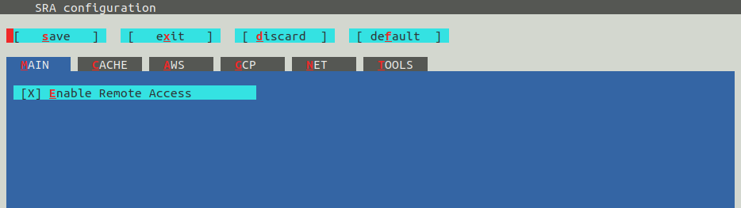

Use the vdb-config window to set the import path to the `sra` directory we just created:

1. Press ‘c’ to navigate to the “CACHE” tab
2. Set the ‘location of the user-repository’ to `sra`:
   1. Press ‘o’ to “choose” the directory
   2. Navigate the directory tree using the up and down arrow keys to select a directory and ‘Enter’ to open directories
   3. When you are in `sra` directory press ‘Tab’, the red indicator will move to ‘OK’, then press ‘Enter’
   4. Then press ‘y’ to confirm
3. Press ‘t’ to move to the “TOOLS” tab
4. Set ‘prefetch downloads to’ to ‘user-repository’ (it may already be set):
   1. Press ‘p’, this should highlight the options
   2. Use the arrow keys to move the asterix to “user-directory”
5. Exit and save:
   1. Press ‘x’ to exit
   2. Press ‘y’ to save changes
   3. press ‘o’ to confirm

### c) Download the set of sra files

We can now directly download the `sra` files. The `sra` file is SRA’s own archive format, but we can extract the raw reads in the more common `.fastq` format in the next step.

To download the sra file we need their accessions numbers. Go to the [SRA Run Selector](https://trace.ncbi.nlm.nih.gov/Traces/study/?go=home) and enter the project number *PRJNA483261*.

“Metadata” –> SraRunTable.txt “Accession List” –> SRR_Acc_List.txt

Use the `prefetch` tool from the sra toolkit to download each file.

```
for sraAcc in `cat SRR_Acc_List.txt`; do
  prefetch ${srrAcc}
done
```

This will download the `sra` files into the `sra` directory. There will be one file for each `SRR` run number in the `SRR_Acc_List.txt` file, these correspond to samples.

### d) Extracting fastq files

We can extract reads from these archive files to `fastq` format files using `fasterq-dump` tool.

```
mkdir fastq
for sraFile in sraDir/sra/*.sra; do
  fasterq-dump -O fastq -e 8 --split-files ${sraFile}
done
```

After each fastq file has been extracted, you should see a message to report have many reads are contained in the file.

Hu, Rui-Si, Jun-Jun He, Hany M. Elsheikha, Yang Zou, Muhammad Ehsan, Qiao-Ni Ma, Xing-Quan Zhu, and Wei Cong. 2020. “Transcriptomic Profiling of Mouse Brain During Acute and Chronic Infections by Toxoplasma Gondii Oocysts.” *Frontiers in Microbiology* 11: 2529. https://doi.org/10.3389/fmicb.2020.570903.